# Régression Ridge et Lasso : prédire le prix de vente d’un logement

Analyse Prédictive, Master 2 Data Science & Systèmes d’Information

Binôme Ridge / Lasso

31/10/2026

# 1 Introduction

Ce rapport accompagne la présentation sur la **régression Ridge et Lasso**. Nous cherchons à prédire le prix de vente d’un logement à partir de ses caractéristiques, sur les ventes réelles de la ville d’Ames (Iowa, États-Unis) entre 2006 et 2010.

Ce jeu de données a une particularité qui convient bien à la méthode : il contient environ quatre-vingts variables décrivant chaque maison, dont plusieurs mesurent presque la même chose (la surface du garage et le nombre de places, par exemple). Une régression linéaire ordinaire y devient instable. Ridge et Lasso ajoutent une pénalité qui stabilise les coefficients, et le Lasso élimine en plus les variables inutiles.

Le rapport suit les points 4.1 à 4.6 du guide méthodologique : cadre théorique, conditions d’application, cas d’application, mise en œuvre sous R, cas pratique et interprétation. Tout le code est exécuté à la compilation, donc les chiffres cités dans le texte sont ceux de la dernière exécution.

# 2 Cadre théorique (4.1)

## 2.1 Origine et auteurs

La régression Ridge a été proposée par Hoerl et Kennard en 1970 pour traiter la colinéarité entre variables explicatives. Le Lasso (*Least Absolute Shrinkage and Selection Operator*) date de 1996 : Robert Tibshirani l’a introduit pour obtenir, en une seule étape, un modèle pénalisé et une sélection de variables. L’Elastic Net, de Zou et Hastie (2005), mélange les deux pénalités. L’implémentation de référence sous R est le package `glmnet` (Friedman, Hastie et Tibshirani).

## 2.2 Principe en mots simples

Une régression linéaire cherche les coefficients qui collent le mieux aux données d’apprentissage. Quand il y a beaucoup de variables, ou des variables très corrélées, elle colle *trop* bien : les coefficients prennent de grandes valeurs de signes opposés qui se compensent, et le modèle se trompe sur de nouvelles données. Ridge et Lasso ajoutent un coût proportionnel à la taille des coefficients. Le modèle accepte alors de coller un peu moins aux données d’apprentissage pour garder des coefficients modérés. On échange un peu de biais contre beaucoup moins de variance.

## 2.3 Formalisation

Soit $y_i$ le prix de la maison $i$, $x_{ij}$ la valeur de sa variable $j$ ($j = 1,\dots,p$) et $\beta$ le vecteur des coefficients. Les variables sont standardisées.

**Moindres carrés ordinaires (MCO)** :
$$\hat\beta^{MCO} = \arg\min_{\beta_0,\beta} \;
\frac{1}{2n}\sum_{i=1}^{n}\Big(y_i-\beta_0-\sum_{j=1}^{p}x_{ij}\beta_j\Big)^2$$

**Ridge** (pénalité $\ell_2$) :
$$\hat\beta^{ridge} = \arg\min_{\beta_0,\beta} \;
\frac{1}{2n}\sum_{i=1}^{n}\Big(y_i-\beta_0-\sum_{j}x_{ij}\beta_j\Big)^2
+ \lambda\,\frac{1}{2}\sum_{j=1}^{p}\beta_j^2$$

**Lasso** (pénalité $\ell_1$) :
$$\hat\beta^{lasso} = \arg\min_{\beta_0,\beta} \;
\frac{1}{2n}\sum_{i=1}^{n}\Big(y_i-\beta_0-\sum_{j}x_{ij}\beta_j\Big)^2
+ \lambda\sum_{j=1}^{p}|\beta_j|$$

**Elastic Net** (forme utilisée par `glmnet`, avec $\alpha\in[0,1]$) :
$$\min_{\beta_0,\beta} \;
\frac{1}{2n}\sum_{i=1}^{n}\big(y_i-\beta_0-x_i^\top\beta\big)^2 +
\lambda\Big[\frac{1-\alpha}{2}\sum_j\beta_j^2+\alpha\sum_j|\beta_j|\Big]$$

$\alpha=0$ donne Ridge, $\alpha=1$ donne Lasso, et $\alpha=0{,}5$ est le mélange à parts égales. Le paramètre $\lambda\ge 0$ règle la force de la pénalité : $\lambda=0$ redonne les MCO, un $\lambda$ très grand écrase tous les coefficients vers 0.

**Ce que la pénalité change concrètement.** La solution de Ridge est explicite :
$$\hat\beta^{ridge}
= (X^\top X + n\lambda I)^{-1}X^\top y$$
Ajouter $n\lambda I$ rend la matrice toujours inversible, même quand deux colonnes de $X$ sont presque identiques. C’est pourquoi Ridge supporte la colinéarité. Pour le Lasso il n’y a pas de formule fermée en général, mais dans le cas simple de colonnes orthogonales ($X^\top X/n = I$) on obtient un *seuillage doux* :
$$\hat\beta_j^{lasso} =
\operatorname{signe}(\hat\beta_j^{MCO})\,\big(|\hat\beta_j^{MCO}|-\lambda\big)_+
\qquad\text{alors que}\qquad
\hat\beta_j^{ridge}=\frac{\hat\beta_j^{MCO}}{1+\lambda}$$
Ridge réduit tous les coefficients dans la même proportion, sans jamais les annuler. Le Lasso retire une quantité fixe et met à zéro ceux qui sont plus petits que $\lambda$. Géométriquement, la contrainte $\ell_1$ a des coins sur les axes, et la solution tombe souvent sur un coin, d’où les coefficients exactement nuls.

**Choix de $\lambda$.** On le choisit par validation croisée à $K=10$ blocs : on retient la valeur `lambda.min` qui minimise l’erreur de validation, ou `lambda.1se`, la plus grande valeur dont l’erreur reste à un écart-type du minimum (modèle plus simple, un peu moins précis).

## 2.4 Variantes et liens avec le reste du cours

| Méthode | Pénalité | Effet sur les variables corrélées | Sélection de variables |
| --- | --- | --- | --- |
| MCO | aucune | coefficients instables | non |
| Ridge | $\sum\beta_j^2$ | partage l’effet entre elles | non (tous les coefficients restent non nuls) |
| Lasso | $\sum\lvert\beta_j\rvert$ | en garde une, souvent au hasard | oui |
| Elastic Net | mélange | garde le groupe, avec des coefficients proches | oui |

Les mêmes pénalités s’appliquent à la régression logistique (`family = "binomial"`), ce qui fait le lien avec le chapitre précédent. Côté concurrents, la sélection pas à pas cherche aussi un modèle parcimonieux, mais de façon instable ; les arbres et forêts aléatoires gèrent seuls les non-linéarités, au prix d’une interprétation moins directe.

# 3 Conditions d’application (4.2)

**Type de cible.** Quantitative pour la régression linéaire pénalisée (notre cas, le prix). Les mêmes pénalités existent pour une cible binaire, multi-classes ou de comptage.

**Hypothèses.**

- La moyenne de la cible est une combinaison linéaire des variables (éventuellement transformées : logarithme, indicatrices, interactions).
- Les observations sont indépendantes.
- Aucune hypothèse de normalité ni d’homoscédasticité n’est nécessaire pour *estimer* le modèle. Elles ne servent que pour les intervalles de confiance classiques, que Ridge et Lasso ne fournissent pas directement.

**Prérequis sur les données.**

- Variables **standardisées** : la pénalité dépend de l’échelle, donc sans standardisation les variables en milliers de pieds carrés seraient moins pénalisées que celles comptées en unités (`glmnet` standardise par défaut).
- Pas de valeurs manquantes : elles se traitent avant (imputation, ou modalité « Missing » pour une variable qualitative).
- Variables qualitatives transformées en indicatrices (une colonne par modalité).
- Aucune contrainte stricte sur $n$ et $p$ : la méthode sert justement quand $p$ est grand, voire plus grand que $n$.

**Quand l’utiliser.** Beaucoup de variables, colinéarité marquée, risque de sur-apprentissage, besoin d’un modèle linéaire lisible. Ridge si l’on pense que beaucoup de variables ont un petit effet ; Lasso si l’on pense que seules quelques-unes comptent.

**Quand l’éviter.** Relations fortement non linéaires ou interactions nombreuses (préférer arbres, forêts, boosting), besoin de valeurs-p et d’intervalles de confiance, ou très peu de variables bien choisies (les MCO suffisent).

**Limites à garder en tête.**

- Les coefficients sont biaisés par construction.
- Le Lasso choisit arbitrairement parmi des variables très corrélées : relancer sur un autre échantillon peut changer la variable retenue.
- Une variable ordinale encodée en indicatrices perd son ordre.

# 4 Cas d’application (4.3)

- **Génomique et santé.** Quelques centaines de patients pour des dizaines de milliers de gènes mesurés : $p$ dépasse $n$ et les MCO ne sont pas définis. Le Lasso retient un petit nombre de gènes associés à la maladie, ce qui donne une liste interprétable.
- **Crédit scoring.** Les dossiers de clients contiennent beaucoup de variables corrélées (revenus, charges, ancienneté, encours). La régression logistique avec pénalité Ridge ou Elastic Net garde des scores stables d’un échantillon à l’autre.
- **Évaluation immobilière.** Notre cas pratique : la valeur d’un bien dépend de dizaines de caractéristiques proches les unes des autres. Un modèle pénalisé reste lisible pour un expert qui doit justifier une estimation.
- **Marketing et prévision de ventes.** Avec de nombreuses variables sur les clients ou les campagnes, le Lasso isole les leviers qui comptent vraiment, utile pour décider où investir.

# 5 Mise en œuvre sous R (4.4)

Le pipeline complet est dans `main.R` (scripts `R/01` à `R/09`). Les fonctions partagées avec l’application Shiny sont dans `R/functions.R`. Voici les étapes exécutées pour ce rapport.

## 5.1 Chargement et exploration

```r
data <- read.csv("data/AmesHousing.csv", stringsAsFactors = FALSE)
dim(data)
```

```
## [1] 2930   82
```

```r
summary(data$saleprice)
```

```
##    Min. 1st Qu.  Median    Mean 3rd Qu.    Max.
##   12789  129500  160000  180796  213500  755000
```

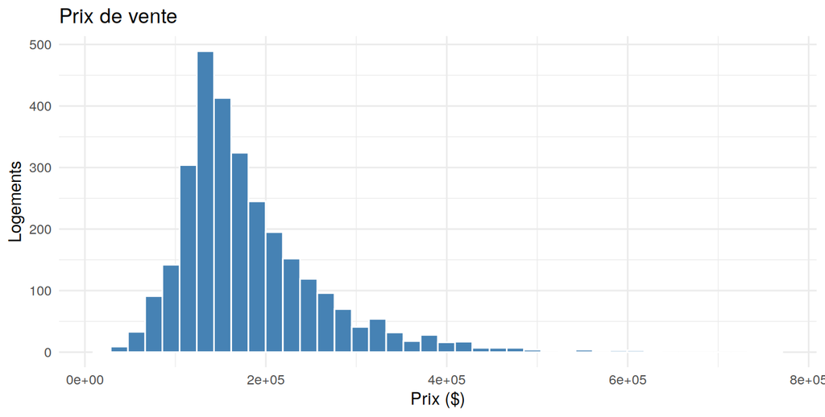

```r
p1 <- ggplot(data, aes(saleprice)) + geom_histogram(bins = 40, fill = "steelblue", color = "white") +
  labs(title = "Prix de vente", x = "Prix ($)", y = "Logements") + theme_minimal()
p2 <- ggplot(data, aes(log(saleprice))) + geom_histogram(bins = 40, fill = "steelblue", color = "white") +
  labs(title = "log(prix de vente)", x = "log(prix)", y = "Logements") + theme_minimal()
gridExtra_ok <- requireNamespace("gridExtra", quietly = TRUE)
if (gridExtra_ok) gridExtra::grid.arrange(p1, p2, ncol = 2) else print(p1)
```

```r
skew <- function(v) mean((v - mean(v))^3) / sd(v)^3
c(prix = skew(data$saleprice), log_prix = skew(log(data$saleprice)))
```

```
##       prix   log_prix
##  1.7417153 -0.0147783
```

Le prix est asymétrique à droite (quelques maisons très chères) ; son logarithme est presque symétrique. Nous modélisons d’abord le prix brut, puis la variante en logarithme (section 7.4).

**Colinéarité entre variables explicatives.** Voici les paires les plus corrélées :

```r
num <- data %>% select(where(is.numeric)) %>% select(-any_of(c("saleprice", "order", "pid")))
cm <- abs(cor(num, use = "pairwise.complete.obs")); cm[lower.tri(cm, diag = TRUE)] <- NA
as.data.frame(as.table(cm)) %>% filter(!is.na(Freq)) %>% arrange(desc(Freq)) %>% head(8) %>%
  transmute(variable_1 = Var1, variable_2 = Var2, correlation = round(Freq, 2)) %>% kable()
```

| variable_1 | variable_2 | correlation |
| --- | --- | --- |
| garage_cars | garage_area | 0.89 |
| year_built | garage_yr_blt | 0.83 |
| gr_liv_area | totrms_abvgrd | 0.81 |
| total_bsmt_sf | X1st_flr_sf | 0.80 |
| bedroom_abvgr | totrms_abvgrd | 0.67 |
| X2nd_flr_sf | gr_liv_area | 0.66 |
| year_remod_add | garage_yr_blt | 0.65 |
| bsmtfin_sf_1 | bsmt_full_bath | 0.64 |

Ces corrélations de 0,8 à 0,9 entre variables explicatives justifient Ridge.

## 5.2 Préparation des données

La fonction `prepare_ames()` fait tout le prétraitement et le découpage 80 % / 20 % :

- les variables qualitatives (`NA` signifie souvent « absent » : pas de garage, pas de piscine) reçoivent la modalité « Missing » ;
- `ms_subclass` et `mo_sold` sont des codes (20, 60, 120… ; 1 à 12) sans ordre numérique : ils sont traités comme des catégories ;
- les valeurs numériques manquantes sont remplacées par la médiane de l’échantillon d’apprentissage ; pour l’année du garage, on prend l’année de construction de la maison (une valeur aberrante de 2207 est corrigée de la même façon) ;
- médianes et modalités sont calculées sur l’apprentissage seul, pour ne rien laisser fuiter du jeu de test ;
- les variables qualitatives deviennent des indicatrices (`dummyVars`).

```r
set.seed(123)
prep <- prepare_ames(data, p = 0.80, seed = 123)
c(apprentissage = nrow(prep$x_train), test = nrow(prep$x_test), colonnes = ncol(prep$x_train))
```

```
## apprentissage          test      colonnes
##          2346           584           339
```

## 5.3 Entraînement par validation croisée

```r
# Une graine avant chaque validation croisée : mêmes blocs que dans R/04, R/05 et R/05b
set.seed(123); cv_ridge <- cv.glmnet(prep$x_train, prep$y_train, alpha = 0,   nfolds = 10)
set.seed(123); cv_lasso <- cv.glmnet(prep$x_train, prep$y_train, alpha = 1,   nfolds = 10)
set.seed(123); cv_enet  <- cv.glmnet(prep$x_train, prep$y_train, alpha = 0.5, nfolds = 10)
c(lambda_ridge = cv_ridge$lambda.min, lambda_lasso = cv_lasso$lambda.min, lambda_enet = cv_enet$lambda.min)
```

```
## lambda_ridge lambda_lasso  lambda_enet
##   25811.5736     556.0935    1112.1870
```

On réajuste ensuite chaque modèle au $\lambda$ retenu (c’est ce que font les scripts `R/04` à `R/05b`).

```r
refit <- function(alpha, lambda) glmnet(prep$x_train, prep$y_train, alpha = alpha, lambda = lambda)
m_ridge <- refit(0,   cv_ridge$lambda.min)
m_lasso <- refit(1,   cv_lasso$lambda.min)
m_enet  <- refit(0.5, cv_enet$lambda.min)
n_nonzero <- function(m) sum(as.numeric(coef(m))[-1] != 0)
```

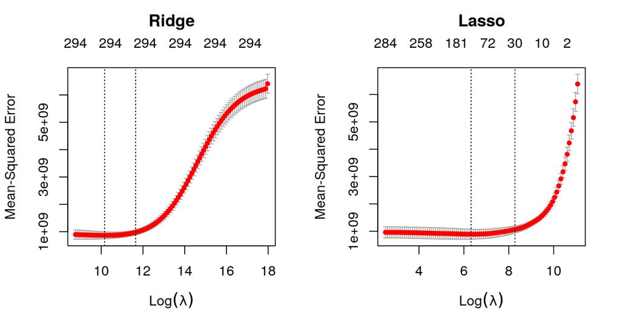

```r
par(mfrow = c(1, 2))
plot(cv_ridge); title("Ridge", line = 2.5)
plot(cv_lasso); title("Lasso", line = 2.5)
```

```r
par(mfrow = c(1, 1))
```

Sur chaque courbe, la première ligne verticale marque `lambda.min`, la seconde `lambda.1se`. Le Lasso tolère un $\lambda$ bien plus petit que Ridge parce que sa pénalité $\ell_1$ n’a pas la même échelle.

**Chemin des coefficients.** Chaque courbe est un coefficient qui se réduit quand $\lambda$ augmente. Avec Ridge, tout s’écrase en douceur ; avec le Lasso, les coefficients tombent à zéro les uns après les autres.

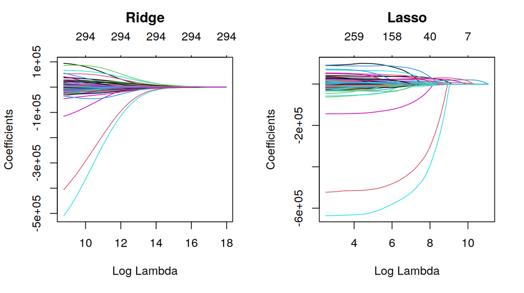

```r
par(mfrow = c(1, 2))
plot(glmnet(prep$x_train, prep$y_train, alpha = 0), xvar = "lambda"); title("Ridge", line = 2.5)
plot(glmnet(prep$x_train, prep$y_train, alpha = 1), xvar = "lambda"); title("Lasso", line = 2.5)
```

```r
par(mfrow = c(1, 1))
```

## 5.4 Évaluation sur le jeu de test

On compare aussi aux MCO, qui servent de point de référence.

```r
pred <- function(m) as.numeric(predict(m, newx = prep$x_test))
pred_1se <- function(cv) as.numeric(predict(cv, newx = prep$x_test, s = "lambda.1se"))
ols  <- suppressWarnings(lm(prep$y_train ~ ., data = as.data.frame(prep$x_train)))
p_ols <- suppressWarnings(as.numeric(predict(ols, as.data.frame(prep$x_test))))

res <- rbind(
  "MCO"                  = metrics_reg(p_ols, prep$y_test),
  "Ridge (lambda.min)"   = metrics_reg(pred(m_ridge), prep$y_test),
  "Lasso (lambda.min)"   = metrics_reg(pred(m_lasso), prep$y_test),
  "Elastic Net (lambda.min)" = metrics_reg(pred(m_enet), prep$y_test),
  "Ridge (lambda.1se)"   = metrics_reg(pred_1se(cv_ridge), prep$y_test),
  "Lasso (lambda.1se)"   = metrics_reg(pred_1se(cv_lasso), prep$y_test)
)
nz <- c(sum(!is.na(coef(ols))[-1]),
        n_nonzero(m_ridge), n_nonzero(m_lasso), n_nonzero(m_enet),
        sum(as.numeric(coef(cv_ridge, s = "lambda.1se"))[-1] != 0),
        sum(as.numeric(coef(cv_lasso, s = "lambda.1se"))[-1] != 0))
tab <- data.frame(Modele = rownames(res), round(res, 3), Variables = nz, row.names = NULL)
tab$RMSE <- round(tab$RMSE); tab$MAE <- round(tab$MAE)
kable(tab, caption = "Performances sur le jeu de test (prix en dollars, R² = 1 - SCR/SCT)")
```

Performances sur le jeu de test (prix en dollars, R² = 1 - SCR/SCT)

| Modele | RMSE | MAE | R2 | Variables |
| --- | --- | --- | --- | --- |
| MCO | 23455 | 14928 | 0.912 | 286 |
| Ridge (lambda.min) | 24161 | 14667 | 0.907 | 294 |
| Lasso (lambda.min) | 23041 | 14078 | 0.915 | 122 |
| Elastic Net (lambda.min) | 23058 | 14062 | 0.915 | 125 |
| Ridge (lambda.1se) | 27974 | 16511 | 0.875 | 294 |
| Lasso (lambda.1se) | 28028 | 17133 | 0.874 | 30 |

Les métriques sont le RMSE (erreur typique, en dollars, qui pénalise les grosses erreurs), le MAE (erreur absolue moyenne) et le $R^2$ calculé comme $1-\text{SCR}/\text{SCT}$.

## 5.5 Interprétation des sorties du modèle

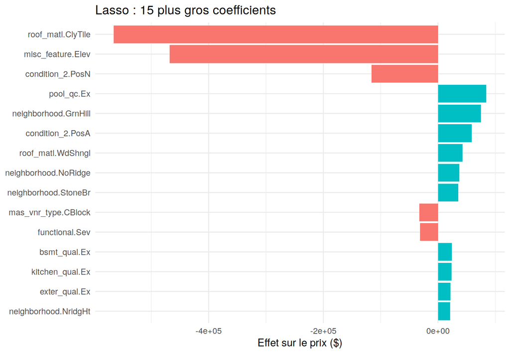

```r
co <- coef(m_lasso)
cdf <- data.frame(variable = rownames(co), coefficient = as.numeric(co)) %>%
  filter(variable != "(Intercept)", coefficient != 0) %>%
  arrange(desc(abs(coefficient))) %>% head(15)
ggplot(cdf, aes(reorder(variable, abs(coefficient)), coefficient, fill = coefficient > 0)) +
  geom_col(show.legend = FALSE) + coord_flip() +
  labs(title = "Lasso : 15 plus gros coefficients", x = NULL, y = "Effet sur le prix ($)") +
  theme_minimal()
```

Un coefficient s’exprime en dollars *pour une hausse d’une unité de la variable, les autres étant fixées*. Les plus gros coefficients concernent surtout des modalités rares (un type de toit présent sur quelques maisons, par exemple) : leur valeur est grande parce que l’estimation repose sur très peu d’observations, pas parce que l’effet est important pour le marché. Pour juger l’importance réelle d’une variable, on regarde plutôt les variables continues et ordinales, qui concernent toutes les maisons :

```r
data.frame(variable = rownames(co), coefficient = round(as.numeric(co), 1)) %>%
  filter(variable %in% c("overall_qual", "gr_liv_area", "garage_cars", "total_bsmt_sf",
                         "year_built", "fireplaces", "full_bath", "bedroom_abvgr")) %>% kable()
```

| variable | coefficient |
| --- | --- |
| overall_qual | 8561.4 |
| year_built | 283.3 |
| total_bsmt_sf | 17.9 |
| gr_liv_area | 52.8 |
| full_bath | 1605.2 |
| bedroom_abvgr | -2859.3 |
| fireplaces | 3463.4 |
| garage_cars | 4149.0 |

## 5.6 Prédiction sur de nouvelles maisons

`make_new_x()` construit la ligne de variables d’une maison décrite par quelques caractéristiques ; les autres prennent une valeur typique.

```r
nouvelles <- list(
  "Maison moyenne (1995, 140 m2)" = list(overall_qual = 6, gr_liv_area = 1500, year_built = 1995,
                                          total_bsmt_sf = 1000, garage_cars = 2, full_bath = 2, bedroom_abvgr = 3),
  "Petite maison ancienne (1950, 85 m2)" = list(overall_qual = 5, gr_liv_area = 950, year_built = 1950,
                                          total_bsmt_sf = 700, garage_cars = 1, full_bath = 1, bedroom_abvgr = 2),
  "Grande maison récente (2005, 250 m2)" = list(overall_qual = 8, gr_liv_area = 2700, year_built = 2005,
                                          total_bsmt_sf = 1400, garage_cars = 3, full_bath = 3, bedroom_abvgr = 4))
do.call(rbind, lapply(names(nouvelles), function(nm) {
  x <- make_new_x(prep, nouvelles[[nm]])
  data.frame(Maison = nm,
             Ridge = fmt(as.numeric(predict(m_ridge, newx = x))),
             Lasso = fmt(as.numeric(predict(m_lasso, newx = x))))
})) %>% kable(caption = "Prix prédits ($)", row.names = FALSE)
```

Prix prédits ($)

| Maison | Ridge | Lasso |
| --- | --- | --- |
| Maison moyenne (1995, 140 m2) | 178 983 | 178 326 |
| Petite maison ancienne (1950, 85 m2) | 122 461 | 112 016 |
| Grande maison récente (2005, 250 m2) | 250 977 | 276 148 |

# 6 Cas pratique : Ames Housing (4.5)

## 6.1 Description du jeu de données

```r
data %>% select(where(is.numeric)) %>% summarise(across(everything(), ~ sum(is.na(.)))) %>%
  pivot_longer(everything(), names_to = "variable", values_to = "nb_na") %>%
  filter(nb_na > 0) %>% arrange(desc(nb_na)) %>% mutate(pourcentage = round(100 * nb_na / nrow(data), 2)) %>% head(6) %>% kable()
```

| variable | nb_na | pourcentage |
| --- | --- | --- |
| lot_frontage | 490 | 16.72 |
| garage_yr_blt | 159 | 5.43 |
| mas_vnr_area | 23 | 0.78 |
| bsmt_full_bath | 2 | 0.07 |
| bsmt_half_bath | 2 | 0.07 |
| bsmtfin_sf_1 | 1 | 0.03 |

## 6.2 Pourquoi ce jeu de données convient à Ridge et Lasso

1. **Beaucoup de variables.** Après encodage, 339 colonnes pour 2346 maisons d’apprentissage.
2. **Colinéarité forte** entre variables explicatives (section 5.1).
3. **Variables inutiles ou redondantes** : le Lasso peut les écarter.
4. **Cible quantitative**, taille raisonnable (quelques milliers de lignes), comme le demande le guide.

# 7 Résultats et interprétation (4.6)

## 7.1 Un seul découpage

Ridge est ici un peu moins bon que les MCO. Ce n’est pas contradictoire avec la théorie : sur un seul échantillon, la différence est du même ordre que le bruit. Il faut regarder plusieurs découpages.

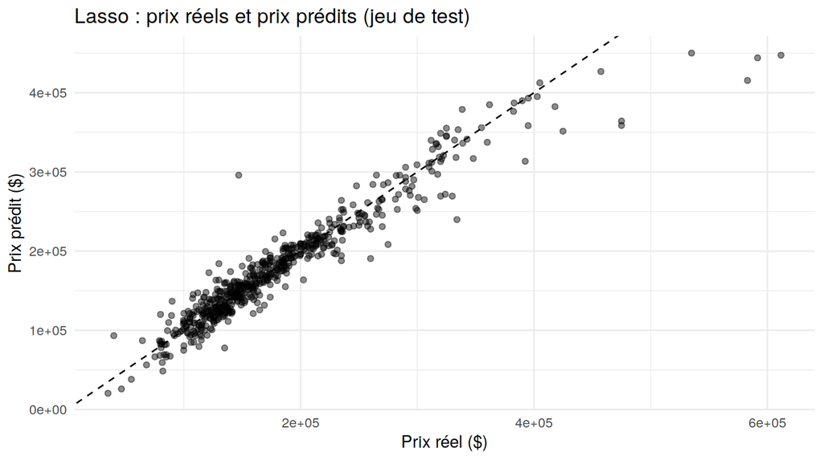

```r
data.frame(reel = prep$y_test, lasso = pred(m_lasso)) %>%
  ggplot(aes(reel, lasso)) + geom_point(alpha = 0.45) + geom_abline(linetype = "dashed") +
  labs(title = "Lasso : prix réels et prix prédits (jeu de test)", x = "Prix réel ($)", y = "Prix prédit ($)") +
  theme_minimal()
```

Les points suivent la diagonale pour les prix courants. Les erreurs les plus grosses concernent les maisons chères (au-delà de 400 000 $), où il y a peu de données et où l’erreur absolue est mécaniquement plus grande.

## 7.2 Dix découpages

```r
if (!file.exists("results/robustesse_decoupages.csv")) {
  d_clean <- data[data$gr_liv_area <= 4000, ]; library(dplyr); source("R/09_robustesse.R")
}
rob <- read.csv("results/robustesse_decoupages.csv", check.names = FALSE, encoding = "UTF-8")
rob %>% group_by(Modele) %>%
  summarise(`RMSE moyen` = round(mean(RMSE)), `Écart-type` = round(sd(RMSE)),
            `RMSE max` = round(max(RMSE)), `R² moyen` = round(mean(R2), 4),
            `Variables (moy.)` = round(mean(Variables)), .groups = "drop") %>%
  arrange(`RMSE moyen`) %>%
  kable(caption = "10 découpages aléatoires, log(prix), sans les 5 atypiques")
```

10 découpages aléatoires, log(prix), sans les 5 atypiques

| Modele | RMSE moyen | Écart-type | RMSE max | R² moyen | Variables (moy.) |
| --- | --- | --- | --- | --- | --- |
| Elastic Net | 19685 | 1050 | 20866 | 0.9368 | 136 |
| Lasso | 19782 | 981 | 20899 | 0.9362 | 128 |
| Ridge | 20003 | 817 | 20936 | 0.9347 | 293 |
| Régression classique (MCO) | 22918 | 5705 | 36578 | 0.9116 | 285 |

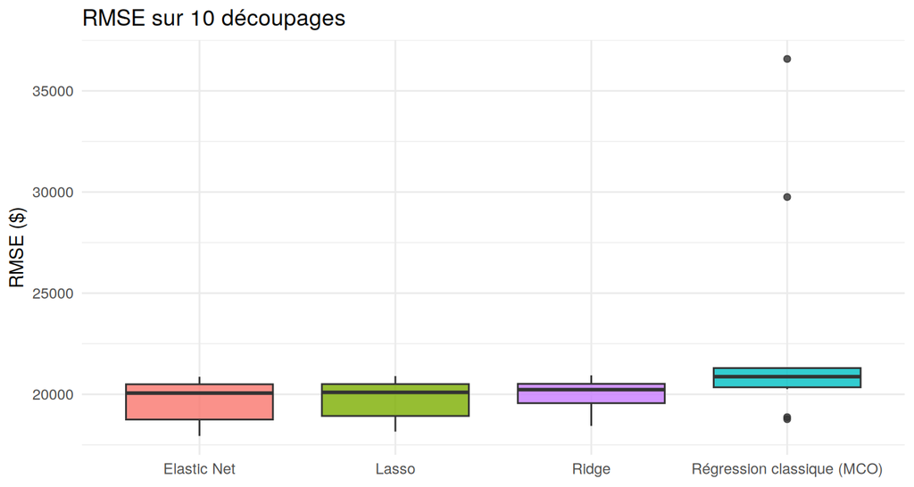

```r
ggplot(rob, aes(reorder(Modele, RMSE), RMSE, fill = Modele)) + geom_boxplot(alpha = .8, show.legend = FALSE) +
  labs(x = NULL, y = "RMSE ($)", title = "RMSE sur 10 découpages") + theme_minimal()
```

Ce tableau change la lecture. Sur la plupart des découpages, les MCO font à peu près aussi bien que les modèles pénalisés. Mais sur certains (le pire : découpage 1, RMSE de 36 578 $), les MCO se dégradent fortement, alors que Ridge, Lasso et Elastic Net restent entre 17 941 et 20 936 $ sur l’ensemble des découpages. L’apport de la pénalisation est donc surtout une question de **stabilité** : les MCO peuvent bien se comporter quelquefois, mais rien ne garantit qu’ils le fassent sur de nouvelles données, ce que la colinéarité rend plausible. Entre Lasso et Elastic Net, l’écart moyen (une centaine de dollars) est bien inférieur à l’écart-type d’un découpage à l’autre : on ne peut pas les départager.

## 7.3 Choix de lambda : `lambda.min` ou `lambda.1se`

Avec `lambda.1se`, le Lasso garde environ une trentaine de variables au lieu de plus de cent, mais l’erreur monte d’environ 5 000 $ (tableau de la section 5.4). On choisit donc `lambda.min` quand la précision prime, et `lambda.1se` si l’on veut un modèle court à expliquer. Pour une estimation immobilière, la précision l’emporte.

## 7.4 Prix brut ou logarithme, avec ou sans atypiques

```r
v <- read.csv("results/variantes.csv", check.names = FALSE, encoding = "UTF-8")
v %>% filter(grepl("MCO", Modele) | Modele %in% c("Ridge", "Lasso", "Elastic Net")) %>%
  select(Variante, Modele, RMSE, MAE, R2, Variables) %>% kable(caption = "Un seul découpage (graine 123)")
```

Un seul découpage (graine 123)

| Variante | Modele | RMSE | MAE | R2 | Variables |
| --- | --- | --- | --- | --- | --- |
| Prix brut, toutes les ventes | Régression classique (MCO) | 23455.0 | 14928.2 | 0.9120 | 286 |
| Prix brut, toutes les ventes | Ridge | 24165.7 | 14672.5 | 0.9065 | 294 |
| Prix brut, toutes les ventes | Lasso | 23046.7 | 14082.5 | 0.9150 | 123 |
| Prix brut, toutes les ventes | Elastic Net | 23063.6 | 14066.5 | 0.9149 | 125 |
| log(prix), toutes les ventes | Régression classique (MCO) | 21186.6 | 13427.7 | 0.9282 | 286 |
| log(prix), toutes les ventes | Ridge | 22506.3 | 14128.0 | 0.9189 | 294 |
| log(prix), toutes les ventes | Lasso | 21249.8 | 13080.7 | 0.9277 | 152 |
| log(prix), toutes les ventes | Elastic Net | 21375.8 | 13093.6 | 0.9269 | 147 |
| Prix brut, sans atypiques | Régression classique (MCO) | 20669.8 | 13448.3 | 0.9336 | 287 |
| Prix brut, sans atypiques | Ridge | 20740.0 | 13077.9 | 0.9332 | 295 |
| Prix brut, sans atypiques | Lasso | 20624.1 | 12989.1 | 0.9339 | 172 |
| Prix brut, sans atypiques | Elastic Net | 20604.5 | 12995.5 | 0.9340 | 179 |
| log(prix), sans atypiques | Régression classique (MCO) | 18049.2 | 12339.9 | 0.9494 | 287 |
| log(prix), sans atypiques | Ridge | 18121.6 | 12143.8 | 0.9490 | 295 |
| log(prix), sans atypiques | Lasso | 18115.8 | 11961.2 | 0.9490 | 148 |
| log(prix), sans atypiques | Elastic Net | 18133.0 | 11936.9 | 0.9489 | 142 |

Le passage au logarithme et le retrait des cinq maisons atypiques font baisser le RMSE de façon nette pour tous les modèles (de plus de 23 000 $ à environ 18 000 $ sur ce découpage). Cela s’explique : on prédit mieux un prix en pourcentage qu’en dollars bruts quand les prix sont asymétriques, et les cinq grandes maisons faussent l’apprentissage. Les coefficients du modèle en logarithme se lisent comme des variations relatives : un coefficient de 0,05 correspond à une hausse d’environ 5 % du prix.

## 7.5 Limites et pistes d’amélioration

- **Modèle linéaire.** Les effets non linéaires (le prix ne croît pas proportionnellement à la surface) et les interactions (qualité × surface) ne sont pas captés. Des termes quadratiques, des interactions choisies ou un modèle d’arbres (forêt, boosting) seraient à comparer.
- **Variables ordinales.** Les notes de qualité (`Ex`, `Gd`, `TA`, `Fa`, `Po`) sont encodées en indicatrices, ce qui ignore leur ordre. Les recoder en 1 à 5 ferait gagner des paramètres.
- **Modalités rares.** Plusieurs coefficients élevés viennent de modalités qui concernent une poignée de maisons. Regrouper les modalités rares aiderait.
- **Pas d’inférence.** Pas d’intervalle de confiance sur les coefficients. Une validation par bootstrap pourrait mesurer la stabilité des variables retenues.
- **Données datées et locales.** Les ventes datent de 2006 à 2010 dans une seule ville. Un modèle appris ici ne se transpose pas à un autre marché ni à une autre période.

# 8 Conclusion

Ridge et Lasso répondent bien au problème posé par ce jeu de données : beaucoup de variables, plusieurs très corrélées. Sur dix découpages, les trois modèles pénalisés donnent des erreurs proches et régulières, là où la régression classique peut décrocher. Le Lasso offre en prime un modèle plus court, avec environ 120 variables au lieu de plus de 280 colonnes. Le logarithme du prix et le retrait des cinq maisons atypiques apportent un gain plus important que le choix entre Ridge, Lasso et Elastic Net.

L’application Shiny du dossier `app/` reprend le modèle de la section 5 : on y règle l’algorithme, $\alpha$, $\lambda$ et le nombre de blocs de validation croisée, on lit les métriques et les coefficients, et on prédit le prix d’une maison saisie à la main.

# 9 Annexe : dictionnaire des variables

```r
read.csv("docs/dictionnaire_variables.csv", encoding = "UTF-8") %>%
  rename(`Valeurs` = valeurs, `NA` = nb_na) %>% kable()
```

[output not shown]

# 10 Annexe : environnement R